[figure not shown]

# Exercises - Basics of Sentiment Analysis with Hugging Face Transformers

*Basics of Python for Data Science*

## Scenario

We will work with a small dataset of Amazon customer reviews of a hair/beard trimmer.

To analyze the text, we will use a **pretrained sentiment analysis model** from [HuggingFace](https://huggingface.co/). The model is based on RoBERTa *(Robustly Optimized BERT [Bidirectional Encoder Representations from Transformers] pretraining Approach)*. Specifically, we will use a model called (`"cardiffnlp/twitter-roberta-base-sentiment"`) which was trained and fine-tuned on Twitter text. I like it because it is quite lightweight and it returns 3 separate sentiment classes: *Negative*, *Neutral*, *Positive*.

(The chosen hair/beard trimmer product is actually reviewed pretty well overall, but I have deliberately sampled similar numbers of reviews for each level of customer ratings/stars ⭐ to ensure more variability… so the dataset is not actually representative of the actual product ratings)

We will:

- Run a pretrained model to perform sentiment analysis on the review texts;
- Assess prediction accuracy (i.e., how well the model prediction actually matches the customer stars ⭐);
- Plot the logistic relationship between model predictions and customer ratings.

## Preliminary Steps

```python
# !pip install transformers
# !pip install torch
# !pip install hf_xet

# import needed packages and functions
import pandas as pd
import numpy as np
import matplotlib.pyplot as plt
import seaborn as sns

import transformers
from sklearn.metrics import confusion_matrix
from torch.nn.functional import softmax
```

## Import and Inspect Dataset

You can download the dataset from: `panasonicTrimmer.xlsx`

It contains customer reviews of a **Panasonic hair/beard trimmer** sold on Amazon, each associated with a short `"Summary"` description, a more extensive `"Text"` review, the number of `"Stars"` rated by the customer (1–5), also manually annotated in a columns names `"trueSentiment"` (1-2 stars: `NEGATIVE`; 3 stars: `NEUTRAL`; 4-5 stars: `POSITIVE`). Let’s inspect it first:

```python
df = pd.read_excel("data/panasonicTrimmer.xlsx")
df.shape
```

```
(60, 4)
```

```python
df.columns
```

```
Index(['Summary', 'Text', 'Stars', 'trueSentiment'], dtype='object')
```

```python
df["Summary"][0:5]
```

```
0         Good trimmer, waterproof
1             Quality hair trimmer
2            One word - Brilliant!
3    Excellent, at half the price!
4                   Ideal Purchase
Name: Summary, dtype: object
```

```python
df["Text"][0:5]
```

```
0    I'm on my second one of these, the first laste...
1    It feels solid, is easy to adjust, and works w...
2    I've been using beard trimmers for approx. 30 ...
3    As described 100%. 'Jobs' done superbly, but I...
4    After many shavers, i finally think this one h...
Name: Text, dtype: object
```

```python
df["Stars"][0:5]
```

```
0    5
1    5
2    5
3    5
4    5
Name: Stars, dtype: int64
```

```python
df["trueSentiment"][0:5]
```

```
0    POSITIVE
1    POSITIVE
2    POSITIVE
3    POSITIVE
4    POSITIVE
Name: trueSentiment, dtype: object
```

## Load the Pretrained Sentiment Model

All we need to do is to create a sentiment analysis pipeline specifying the `model` name and the `task` that it is required to do. The model is hosted on [HuggingFace](https://huggingface.co/) (we must specify the exact `"Model Name"`), and it is automatically accessed by `transformers`.

```python
classifier = transformers.pipeline(task="sentiment-analysis",
                                  model="cardiffnlp/twitter-roberta-base-sentiment")
```

## Run the Sentiment Analysis Task for each Review

Just for fun and practice, let’s try running the classifier pipeline on a single line of text:

```python
classifier("Wow, this product is great! :-D")
```

```
[{'label': 'LABEL_2', 'score': 0.9924255609512329}]
```

Ok, if you try a bit you will realize that for any piece of text it returns two elements:

- *`"label"`* which is the predicted sentiment class, it is not directly interpretable, but like:
  - `"LABEL_0"` → `"NEGATIVE"`;
  - `"LABEL_1"` → `"NEUTRAL"`;
  - `"LABEL_2"` → `"POSITIVE"` (we need to keep this in mind and convert those later for interpretability);
- *`"score"`* a confidence value between 0 and 1 indicating the model certainty.

Now, let’s run the `classifier` pipeline on every single cell on the `"Text"` column of our dataframe, and store the results in a list (using *list comprehension*)

```python
pred = [classifier(t)[0] for t in df["Text"]]
```

Let’s convert the result into a DataFrame for easier manipulation:

```python
pred = pd.DataFrame(pred)
```

Now, for ease of “human” readability, let’s convert the labels using the **`np.select()`** function:

```python
conditions = [pred["label"]=="LABEL_0", pred["label"]=="LABEL_1", pred["label"]=="LABEL_2"]
labels = ["NEGATIVE", "NEUTRAL", "POSITIVE"]
df["predictedSentiment"] = np.select(conditions, labels, default="")
```

## Evaluate Predictions

To assess how well the model is performing, we can compare the predictions (`predictedSentiment`) to the ground-truth labels in our dataset (`trueSentiment`). To do so, we can compute a **confusion matrix**: it will tell us how many `"POSITIVE"` reviews as predicted by the model actually corresponds to ratings of 4-5 stars by the customer, and so on.

We can use the `confusion_matrix()` function from the `sklearn.metrics` submodule, which is analogous to the `table()` function in R

```python
CM = confusion_matrix(df["trueSentiment"], df["predictedSentiment"], labels=labels)
print(CM)
```

```
[[17  1  2]
 [10  7  3]
 [ 1  1 18]]
```

For readability, we can transform the counts into proportions (0 to 1, row-wise):

```python
print(CM / CM.sum(1))
```

```
[[0.85 0.05 0.1 ]
 [0.5  0.35 0.15]
 [0.05 0.05 0.9 ]]
```

**Question:** which “sentiment” is more easily confused? why?

## From Classification to Continuous Sentiment Valence

I actually don’t like categorical classification very much. I would prefer to obtain a **continuum score of valence** where one extreme is absolutely negative, and the other is absolutely positive. In fact, our model was trained to assign discrete labels. However, it generates underlying **logit scores** that reflect its confidence for each sentiment class. We can use those as proxies to compute a single continuous valence score.

Now, this is a bit technical: instead of relying on the `pipeline`, we need to separately *tokenize* the sentence and apply the *model*

- First, let’s tokenize the sentence

```python
tokenizer = transformers.AutoTokenizer.from_pretrained("cardiffnlp/twitter-roberta-base-sentiment")

tokenSentence = tokenizer("My day was so-so, but afterall not so bad", return_tensors="pt")
print(tokenSentence)
```

```
{'input_ids': tensor([[   0, 2387,  183,   21,   98,   12, 2527,    6,   53,   71, 1250,   45,
           98, 1099,    2]]), 'attention_mask': tensor([[1, 1, 1, 1, 1, 1, 1, 1, 1, 1, 1, 1, 1, 1, 1]])}
```

- Second, let’s run the model on the tensor of tokens and extract the logits (the first score is for *negative*, the second for *neutral*, the third for *positive*):

```python
model = transformers.AutoModelForSequenceClassification.from_pretrained("cardiffnlp/twitter-roberta-base-sentiment")

logitScores = model(input_ids=tokenSentence["input_ids"],
               attention_mask=tokenSentence["attention_mask"]).logits
print(logitScores)
```

```
tensor([[ 0.4030,  0.2260, -0.6003]], grad_fn=<AddmmBackward0>)
```

- Third, let’s convert logits to probabilities. A logit score can directly be converted into probability; more logit scores can be normalized to probabilities that cumulatively add to one. We can use the `softmax()` function (from the `torch.nn.functional` submodule; `dim=1` tells the function that it must be computed row-wise):

*note: softmax does like:* $\frac{e^{0.4030}}{e^{0.4030} + e^{0.2260} + e^{-0.6003}} = 0.4536$

```python
probs = softmax(logitScores, dim=1)
print(probs)
```

```
tensor([[0.4536, 0.3800, 0.1663]], grad_fn=<SoftmaxBackward0>)
```

- Finally, to summarize valence as one single score, we could multiply *negative* -1 times, *neutral* 0 times, *positive* +1 times, so the final score will be in a continuous range of [-1, 1]:

```python
probs[0][0]*(-1) + probs[0][1] * 0 + probs[0][2] * (+1)
```

```
tensor(-0.2873, grad_fn=<AddBackward0>)
```

Good! Now let’s compute all of this for every customer review:

```python
df["valence"] = np.nan
for i in range(len(df["Text"])):
    sentence = tokenizer(df["Text"][i], return_tensors="pt")  # encode sentence
    logitScores = model(**sentence).logits                    # forward pass
    probs = softmax(logitScores, dim=1)                       # convert to probabilities
    df.loc[i, "valence"] = float(probs[0][0]*(-1) +           # weighted sum: neg = -1
                                 probs[0][1]*0 +              # neutral = 0
                                 probs[0][2]*(+1))            # pos = +1
df.head()
```

```
                         Summary  ...   valence
0       Good trimmer, waterproof  ...  0.909970
1           Quality hair trimmer  ...  0.651900
2          One word - Brilliant!  ...  0.980573
3  Excellent, at half the price!  ...  0.896451
4                 Ideal Purchase  ...  0.958984

[5 rows x 6 columns]
```

### Scatter Plot of predicted `valence` vs customers’ ratings `stars`

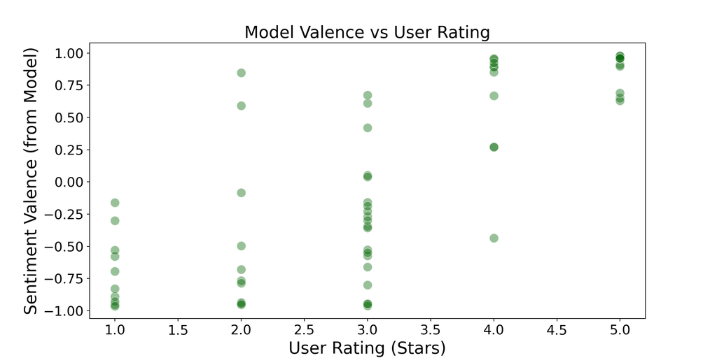

```python
plt.figure(figsize=(12,6))
sns.scatterplot(x=df["Stars"], y=df["valence"], alpha=0.4, s=120, color="darkgreen")
plt.title("Model Valence vs User Rating", fontsize=20)
plt.xlabel("User Rating (Stars)", fontsize=20)
plt.ylabel("Sentiment Valence (from Model)", fontsize=20)
plt.xticks(fontsize=16);
plt.yticks(fontsize=16);
plt.show()
```

```python
plt.clf(); plt.close()
```

*Is there a clear relationship between model valence and actual star ratings?*

### Fit a Logistic Regression

Finally, let’s plot a regression line. But we must be careful: since `valence` is bounded, the relation should not be modeled as linear. Rather, it could be *logistic* curve. For convenience, let’s first rescale valence from [-1, 1] to [0, 1], and then run a `seaborn` `regplot` with a `logistic` regression:

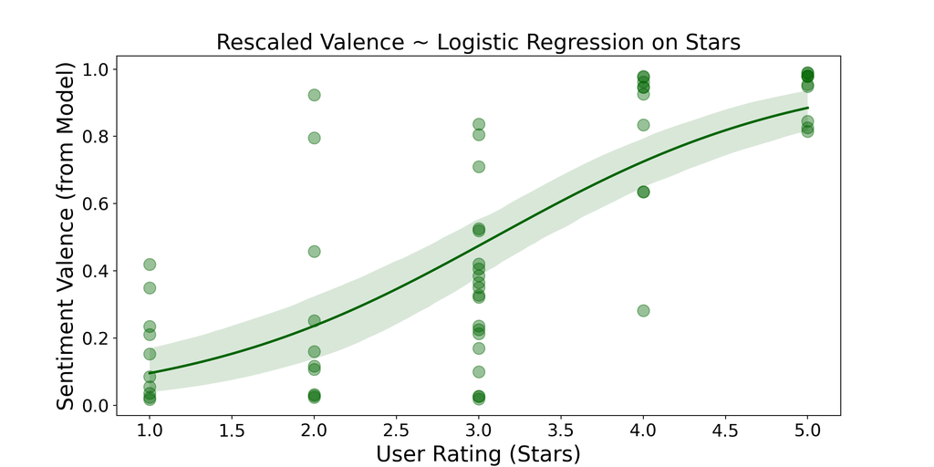

```python
# rescale valence from [−1, +1] → [0, 1] for logistic model
df["valenceRescaled"] = (df["valence"] + 1) / 2

# fit and plot logistic regression: stars → valence
plt.figure(figsize=(12,6))
sns.regplot(x=df["Stars"], y=df["valenceRescaled"], logistic=True,
              scatter_kws={"alpha": 0.4, "s":120}, color="darkgreen")
plt.title("Rescaled Valence ~ Logistic Regression on Stars", fontsize=20)
plt.xlabel("User Rating (Stars)", fontsize=20)
plt.ylabel("Sentiment Valence (from Model)", fontsize=20)
plt.xticks(fontsize=16);
plt.yticks(fontsize=16);
plt.show()
```

```python
plt.clf(); plt.close()
```

## What could you do now?

- Try to rerun all of the above, but first combine the `"Summary"` column with the more extensive `"Text"` review column (this should improve classification ability even further, because it adds very dense information);
- Try other *sentiment models* (e.g. search `"sentiment"` on [HuggingFace](https://huggingface.co/));
- Find out mismatches: try the above pipeline with different types of text and find out where the model possibly disagree strongly with human labels;
- Translate the reviews and test if the model still works on non-English texts, then find best models for non-English text.

**Be careful, the model is not so specific**

As said above, this model was trained on **Twitter texts**. Domain shift (e.g., Amazon reviews) can make the performance suboptimal